# Data and point plots

Introduces the distinction between quantitative and categorical variables through their very different appearances in a point plot.

Daniel Kaplan https://dtkaplan.github.io  
2020-06-16

Alternative document formats: Word & PDF

# Orientation

Data can be many things, but one of the most common formats is a data frame, a kind of spreadsheet of rows and columns. We’ll work with the data frame (or data set) `Natality_2014` in the Source pakage `Little Apps`, which is based on data published by the US Centers for Disease Control. `Natality_2014` has 100,000 rows. Each row reports a live birth in the US in 2014. There are dozens of variables, a few of which are shown below.

|  | sex | dbwt | combgest | me_rout | mager | wic |
| --- | --- | --- | --- | --- | --- | --- |
| 1 | M | 3735 | 44 | spontaneous | 30 | n |
| 2 | M | 3260 | 35 | spontaneous | 18 | n |
| 3 | F | 3110 | 39 | spontaneous | 20 | n |
| 4 | M | 3515 | 41 | spontaneous | 26 |  |
| 5 | M | 4338 | 40 | spontaneous | 31 | n |
| 6 | F | 2835 | 39 | cesarean | 33 | y |
| 7 | M | 2778 | 36 | cesarean | 23 | n |
| 8 | M | 615 | 23 | spontaneous | 32 | n |
| 9 | F | 3450 | 39 | spontaneous | 33 | n |
| 10 | F | 3205 | 39 | spontaneous | 31 | n |

[output cut: 90 more lines]

It’s hard to draw much of a conclusion by looking directly at a large data frame. But a graphical display of data can help.

A *point plot*[^1] is a basic statistical graphic that displays two variables from a data frame. One variable is represented on the vertical axis, another variable on the horizontal axis. Like the following point plot of the baby’s weight (in grams) (`dbwt`) and the length (in weeks) of the pregnancy (`combgest`).

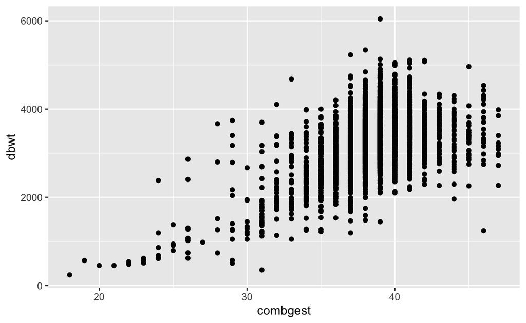

# Exercise

# Activity

Open the [Regression Little App](https://maa-statprep.shinyapps.io/Little_App_Regression/). (See footnote[^2]).

1. Set the Source package to `Little Apps`, data set to `Natality_2014`. Choose `dbwt` as the response variable and `combgest` as the explanatory variable. The resulting plot should look much like the graph seen in the introduction to this lesson. Change the sample size to $n = 5$ by cliciking on the n=50 icon and choosing n=5. Click on the Graph tab in the top tool bar to see a larger graph.
2. In the “Data” tab in the top tool bar you will see the graph and the data that is in the plot, in data-frame format.
   - For each of the $n=5$ rows of the data frame, find the corresponding point in the graphic.*
3. Change the *explanatory* variable to `sex`.
   - For each of the $n=5$ rows of the data frame displayed in the Data tab, find the corresponding point in the graphic.
   - Change $n$ to 500. In the `baby_wt` versus `sex` graph, all the points are lined up in two columns.

   *Explain why.* . . .

Version 0.3, 2020-08-13